# Risk Factor Analysis

## Outcome Variable

**Outcome Variable:** haz

## Predictor Variables

**Intervention Variable:** nchldlt5

**Adjustment Set:**

- arm
- W_mage
- meducyrs
- feducyrs
- hhwealth_quart
- hfoodsec
- W_mhtcm
- W_mwtkg
- W_mbmi
- W_nrooms
- W_parity
- impfloor
- impsan
- safeh20
- delta_W_mage
- delta_meducyrs
- delta_feducyrs
- delta_hhwealth_quart
- delta_hfoodsec
- delta_W_mhtcm
- delta_W_mwtkg
- delta_W_mbmi
- delta_W_nrooms
- delta_W_parity
- delta_impfloor
- delta_impsan
- delta_safeh20

## Stratifying Variables

The analysis was stratified on these variable(s):

- agecat
- studyid
- country

## Data Summary

| agecat | studyid | country | nchldlt5 | n_cell | n |
| --- | --- | --- | --- | --- | --- |
| Birth | ki1000108-IRC | INDIA | 1 | 84 | 388 |
| Birth | ki1000108-IRC | INDIA | 2+ | 304 | 388 |
| Birth | ki1017093b-PROVIDE | BANGLADESH | 1 | 391 | 539 |
| Birth | ki1017093b-PROVIDE | BANGLADESH | 2+ | 148 | 539 |
| Birth | ki1017093c-NIH-Crypto | BANGLADESH | 1 | 522 | 732 |
| Birth | ki1017093c-NIH-Crypto | BANGLADESH | 2+ | 210 | 732 |
| Birth | kiGH5241-JiVitA-3 | BANGLADESH | 1 | 16975 | 26641 |
| Birth | kiGH5241-JiVitA-3 | BANGLADESH | 2+ | 9666 | 26641 |
| 6 months | ki1000108-IRC | INDIA | 1 | 89 | 407 |
| 6 months | ki1000108-IRC | INDIA | 2+ | 318 | 407 |
| 6 months | ki1017093b-PROVIDE | BANGLADESH | 1 | 438 | 604 |
| 6 months | ki1017093b-PROVIDE | BANGLADESH | 2+ | 166 | 604 |
| 6 months | ki1017093c-NIH-Crypto | BANGLADESH | 1 | 507 | 715 |
| 6 months | ki1017093c-NIH-Crypto | BANGLADESH | 2+ | 208 | 715 |
| 6 months | ki1066203-TanzaniaChild2 | TANZANIA, UNITED REPUBLIC OF | 1 | 1391 | 2020 |
| 6 months | ki1066203-TanzaniaChild2 | TANZANIA, UNITED REPUBLIC OF | 2+ | 629 | 2020 |
| 6 months | ki1148112-LCNI-5 | MALAWI | 1 | 390 | 811 |
| 6 months | ki1148112-LCNI-5 | MALAWI | 2+ | 421 | 811 |
| 6 months | kiGH5241-JiVitA-3 | BANGLADESH | 1 | 10849 | 16742 |
| 6 months | kiGH5241-JiVitA-3 | BANGLADESH | 2+ | 5893 | 16742 |
| 24 months | ki1000108-IRC | INDIA | 1 | 89 | 409 |
| 24 months | ki1000108-IRC | INDIA | 2+ | 320 | 409 |
| 24 months | ki1017093b-PROVIDE | BANGLADESH | 1 | 424 | 578 |
| 24 months | ki1017093b-PROVIDE | BANGLADESH | 2+ | 154 | 578 |
| 24 months | ki1017093c-NIH-Crypto | BANGLADESH | 1 | 357 | 514 |
| 24 months | ki1017093c-NIH-Crypto | BANGLADESH | 2+ | 157 | 514 |
| 24 months | ki1066203-TanzaniaChild2 | TANZANIA, UNITED REPUBLIC OF | 1 | 5 | 6 |
| 24 months | ki1066203-TanzaniaChild2 | TANZANIA, UNITED REPUBLIC OF | 2+ | 1 | 6 |
| 24 months | ki1148112-LCNI-5 | MALAWI | 1 | 283 | 571 |
| 24 months | ki1148112-LCNI-5 | MALAWI | 2+ | 288 | 571 |
| 24 months | kiGH5241-JiVitA-3 | BANGLADESH | 1 | 5412 | 8555 |
| 24 months | kiGH5241-JiVitA-3 | BANGLADESH | 2+ | 3143 | 8555 |

The following strata were considered:

- agecat: 24 months, studyid: ki1000108-IRC, country: INDIA
- agecat: 24 months, studyid: ki1017093b-PROVIDE, country: BANGLADESH
- agecat: 24 months, studyid: ki1017093c-NIH-Crypto, country: BANGLADESH
- agecat: 24 months, studyid: ki1066203-TanzaniaChild2, country: TANZANIA, UNITED REPUBLIC OF
- agecat: 24 months, studyid: ki1148112-LCNI-5, country: MALAWI
- agecat: 24 months, studyid: kiGH5241-JiVitA-3, country: BANGLADESH
- agecat: 6 months, studyid: ki1000108-IRC, country: INDIA
- agecat: 6 months, studyid: ki1017093b-PROVIDE, country: BANGLADESH
- agecat: 6 months, studyid: ki1017093c-NIH-Crypto, country: BANGLADESH
- agecat: 6 months, studyid: ki1066203-TanzaniaChild2, country: TANZANIA, UNITED REPUBLIC OF
- agecat: 6 months, studyid: ki1148112-LCNI-5, country: MALAWI
- agecat: 6 months, studyid: kiGH5241-JiVitA-3, country: BANGLADESH
- agecat: Birth, studyid: ki1000108-IRC, country: INDIA
- agecat: Birth, studyid: ki1017093b-PROVIDE, country: BANGLADESH
- agecat: Birth, studyid: ki1017093c-NIH-Crypto, country: BANGLADESH
- agecat: Birth, studyid: kiGH5241-JiVitA-3, country: BANGLADESH

### Dropped Strata

Some strata were dropped due to rare outcomes:

- agecat: 24 months, studyid: ki1066203-TanzaniaChild2, country: TANZANIA, UNITED REPUBLIC OF

## Methods Detail

We’re interested in the causal parameters $E[Y_a]$ for all values of $a \in \mathcal{A}$. These parameters represent the mean outcome if, possibly contrary to fact, we intervened to set all units to have $A=a$. Under the randomization and positivity assumptions, these are identified by the statistical parameters $\psi_a=E_W[E_{Y|A,W}(Y|A=a,W)]$. In addition, we’re interested in the mean of $Y$, $E[Y]$ under no intervention (the observed mean). We will estimate these parameters by using SuperLearner to fit the relevant likelihood factors – $E_{Y|A,W}(Y|A=a,W)$ and $p(A=a|W)$, and then updating our likelihood fit using a joint TMLE.

For unadjusted analyses ($W=\{\}$), initial likelihoods were estimated using Lrnr_glm to estimate the simple $E(Y|A)$ and Lrnr_mean to estimate $p(A)$. For adjusted analyses, a small library containing Lrnr_glmnet, Lrnr_xgboost, and Lrnr_mean was used.

Having estimated these parameters, we will then use the delta method to estimate relative risks and attributable risks relative to a prespecified baseline level of $A$.

# Results Detail

## Results Plots

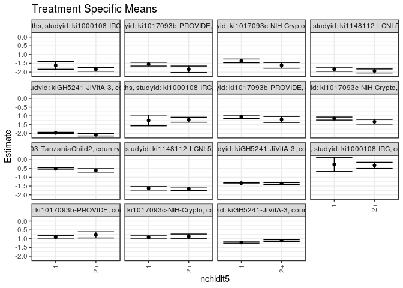

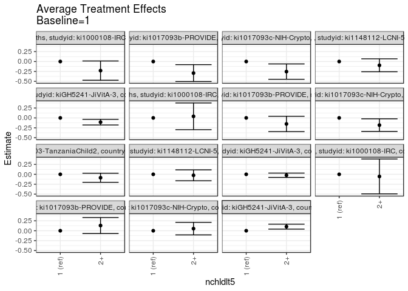

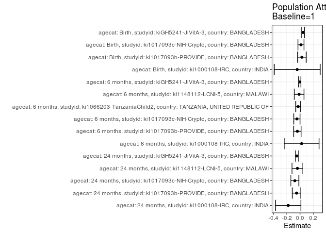

## Results Table

### Parameter: TSM

| agecat | studyid | country | intervention_level | baseline_level | estimate | ci_lower | ci_upper |
| --- | --- | --- | --- | --- | --- | --- | --- |
| Birth | ki1000108-IRC | INDIA | 1 | NA | -0.2645557 | -0.6675306 | 0.1384193 |
| Birth | ki1000108-IRC | INDIA | 2+ | NA | -0.3180083 | -0.4926267 | -0.1433899 |
| Birth | ki1017093b-PROVIDE | BANGLADESH | 1 | NA | -0.9129961 | -1.0146885 | -0.8113038 |
| Birth | ki1017093b-PROVIDE | BANGLADESH | 2+ | NA | -0.7822520 | -0.9586006 | -0.6059034 |
| Birth | ki1017093c-NIH-Crypto | BANGLADESH | 1 | NA | -0.9233090 | -1.0091031 | -0.8375149 |
| Birth | ki1017093c-NIH-Crypto | BANGLADESH | 2+ | NA | -0.8704783 | -1.0037591 | -0.7371974 |
| Birth | kiGH5241-JiVitA-3 | BANGLADESH | 1 | NA | -1.2181162 | -1.2542739 | -1.1819584 |
| Birth | kiGH5241-JiVitA-3 | BANGLADESH | 2+ | NA | -1.1144913 | -1.1703114 | -1.0586712 |
| 6 months | ki1000108-IRC | INDIA | 1 | NA | -1.2580818 | -1.5653321 | -0.9508314 |
| 6 months | ki1000108-IRC | INDIA | 2+ | NA | -1.2178169 | -1.3598284 | -1.0758054 |
| 6 months | ki1017093b-PROVIDE | BANGLADESH | 1 | NA | -1.0512549 | -1.1448519 | -0.9576580 |
| 6 months | ki1017093b-PROVIDE | BANGLADESH | 2+ | NA | -1.2034187 | -1.3730705 | -1.0337668 |
| 6 months | ki1017093c-NIH-Crypto | BANGLADESH | 1 | NA | -1.1512416 | -1.2373146 | -1.0651687 |
| 6 months | ki1017093c-NIH-Crypto | BANGLADESH | 2+ | NA | -1.3332337 | -1.4667824 | -1.1996851 |
| 6 months | ki1066203-TanzaniaChild2 | TANZANIA, UNITED REPUBLIC OF | 1 | NA | -0.5160617 | -0.5758913 | -0.4562322 |
| 6 months | ki1066203-TanzaniaChild2 | TANZANIA, UNITED REPUBLIC OF | 2+ | NA | -0.6026135 | -0.7014960 | -0.5037310 |
| 6 months | ki1148112-LCNI-5 | MALAWI | 1 | NA | -1.6287457 | -1.7292527 | -1.5282386 |
| 6 months | ki1148112-LCNI-5 | MALAWI | 2+ | NA | -1.6538687 | -1.7501275 | -1.5576099 |
| 6 months | kiGH5241-JiVitA-3 | BANGLADESH | 1 | NA | -1.3317106 | -1.3603757 | -1.3030456 |
| 6 months | kiGH5241-JiVitA-3 | BANGLADESH | 2+ | NA | -1.3553650 | -1.4066592 | -1.3040708 |
| 24 months | ki1000108-IRC | INDIA | 1 | NA | -1.6196327 | -1.8388629 | -1.4004025 |
| 24 months | ki1000108-IRC | INDIA | 2+ | NA | -1.8488467 | -1.9535730 | -1.7441205 |
| 24 months | ki1017093b-PROVIDE | BANGLADESH | 1 | NA | -1.5492127 | -1.6561790 | -1.4422465 |
| 24 months | ki1017093b-PROVIDE | BANGLADESH | 2+ | NA | -1.8410102 | -2.0248600 | -1.6571604 |
| 24 months | ki1017093c-NIH-Crypto | BANGLADESH | 1 | NA | -1.3626438 | -1.4668607 | -1.2584268 |
| 24 months | ki1017093c-NIH-Crypto | BANGLADESH | 2+ | NA | -1.6173085 | -1.7805043 | -1.4541127 |
| 24 months | ki1148112-LCNI-5 | MALAWI | 1 | NA | -1.8405783 | -1.9560500 | -1.7251065 |
| 24 months | ki1148112-LCNI-5 | MALAWI | 2+ | NA | -1.9360347 | -2.0506812 | -1.8213882 |
| 24 months | kiGH5241-JiVitA-3 | BANGLADESH | 1 | NA | -1.9706544 | -2.0064999 | -1.9348089 |
| 24 months | kiGH5241-JiVitA-3 | BANGLADESH | 2+ | NA | -2.0780264 | -2.1434238 | -2.0126291 |

### Parameter: E(Y)

| agecat | studyid | country | intervention_level | baseline_level | estimate | ci_lower | ci_upper |
| --- | --- | --- | --- | --- | --- | --- | --- |
| Birth | ki1000108-IRC | INDIA | NA | NA | -0.3080412 | -0.4687931 | -0.1472894 |
| Birth | ki1017093b-PROVIDE | BANGLADESH | NA | NA | -0.8851020 | -0.9601332 | -0.8100709 |
| Birth | ki1017093c-NIH-Crypto | BANGLADESH | NA | NA | -0.9094945 | -0.9809370 | -0.8380521 |
| Birth | kiGH5241-JiVitA-3 | BANGLADESH | NA | NA | -1.1729473 | -1.2010166 | -1.1448781 |
| 6 months | ki1000108-IRC | INDIA | NA | NA | -1.2344062 | -1.3658524 | -1.1029600 |
| 6 months | ki1017093b-PROVIDE | BANGLADESH | NA | NA | -1.0916915 | -1.1661176 | -1.0172654 |
| 6 months | ki1017093c-NIH-Crypto | BANGLADESH | NA | NA | -1.1986783 | -1.2700937 | -1.1272630 |
| 6 months | ki1066203-TanzaniaChild2 | TANZANIA, UNITED REPUBLIC OF | NA | NA | -0.5442232 | -0.5932373 | -0.4952090 |
| 6 months | ki1148112-LCNI-5 | MALAWI | NA | NA | -1.6431566 | -1.7128296 | -1.5734836 |
| 6 months | kiGH5241-JiVitA-3 | BANGLADESH | NA | NA | -1.3356337 | -1.3587165 | -1.3125509 |
| 24 months | ki1000108-IRC | INDIA | NA | NA | -1.7987775 | -1.8923914 | -1.7051636 |
| 24 months | ki1017093b-PROVIDE | BANGLADESH | NA | NA | -1.6024221 | -1.6857420 | -1.5191023 |
| 24 months | ki1017093c-NIH-Crypto | BANGLADESH | NA | NA | -1.4412646 | -1.5249156 | -1.3576135 |
| 24 months | ki1148112-LCNI-5 | MALAWI | NA | NA | -1.8806830 | -1.9625334 | -1.7988326 |
| 24 months | kiGH5241-JiVitA-3 | BANGLADESH | NA | NA | -2.0193641 | -2.0469959 | -1.9917323 |

### Parameter: ATE

| agecat | studyid | country | intervention_level | baseline_level | estimate | ci_lower | ci_upper |
| --- | --- | --- | --- | --- | --- | --- | --- |
| Birth | ki1000108-IRC | INDIA | 1 | 1 | 0.0000000 | 0.0000000 | 0.0000000 |
| Birth | ki1000108-IRC | INDIA | 2+ | 1 | -0.0534526 | -0.4927934 | 0.3858882 |
| Birth | ki1017093b-PROVIDE | BANGLADESH | 1 | 1 | 0.0000000 | 0.0000000 | 0.0000000 |
| Birth | ki1017093b-PROVIDE | BANGLADESH | 2+ | 1 | 0.1307441 | -0.0708401 | 0.3323283 |
| Birth | ki1017093c-NIH-Crypto | BANGLADESH | 1 | 1 | 0.0000000 | 0.0000000 | 0.0000000 |
| Birth | ki1017093c-NIH-Crypto | BANGLADESH | 2+ | 1 | 0.0528308 | -0.1054637 | 0.2111252 |
| Birth | kiGH5241-JiVitA-3 | BANGLADESH | 1 | 1 | 0.0000000 | 0.0000000 | 0.0000000 |
| Birth | kiGH5241-JiVitA-3 | BANGLADESH | 2+ | 1 | 0.1036249 | 0.0409679 | 0.1662818 |
| 6 months | ki1000108-IRC | INDIA | 1 | 1 | 0.0000000 | 0.0000000 | 0.0000000 |
| 6 months | ki1000108-IRC | INDIA | 2+ | 1 | 0.0402648 | -0.2967220 | 0.3772516 |
| 6 months | ki1017093b-PROVIDE | BANGLADESH | 1 | 1 | 0.0000000 | 0.0000000 | 0.0000000 |
| 6 months | ki1017093b-PROVIDE | BANGLADESH | 2+ | 1 | -0.1521637 | -0.3458240 | 0.0414966 |
| 6 months | ki1017093c-NIH-Crypto | BANGLADESH | 1 | 1 | 0.0000000 | 0.0000000 | 0.0000000 |
| 6 months | ki1017093c-NIH-Crypto | BANGLADESH | 2+ | 1 | -0.1819921 | -0.3409755 | -0.0230087 |
| 6 months | ki1066203-TanzaniaChild2 | TANZANIA, UNITED REPUBLIC OF | 1 | 1 | 0.0000000 | 0.0000000 | 0.0000000 |
| 6 months | ki1066203-TanzaniaChild2 | TANZANIA, UNITED REPUBLIC OF | 2+ | 1 | -0.0865518 | -0.2012022 | 0.0280987 |
| 6 months | ki1148112-LCNI-5 | MALAWI | 1 | 1 | 0.0000000 | 0.0000000 | 0.0000000 |
| 6 months | ki1148112-LCNI-5 | MALAWI | 2+ | 1 | -0.0251230 | -0.1624313 | 0.1121853 |
| 6 months | kiGH5241-JiVitA-3 | BANGLADESH | 1 | 1 | 0.0000000 | 0.0000000 | 0.0000000 |
| 6 months | kiGH5241-JiVitA-3 | BANGLADESH | 2+ | 1 | -0.0236544 | -0.0782124 | 0.0309037 |
| 24 months | ki1000108-IRC | INDIA | 1 | 1 | 0.0000000 | 0.0000000 | 0.0000000 |
| 24 months | ki1000108-IRC | INDIA | 2+ | 1 | -0.2292140 | -0.4723342 | 0.0139062 |
| 24 months | ki1017093b-PROVIDE | BANGLADESH | 1 | 1 | 0.0000000 | 0.0000000 | 0.0000000 |
| 24 months | ki1017093b-PROVIDE | BANGLADESH | 2+ | 1 | -0.2917975 | -0.5042416 | -0.0793534 |
| 24 months | ki1017093c-NIH-Crypto | BANGLADESH | 1 | 1 | 0.0000000 | 0.0000000 | 0.0000000 |
| 24 months | ki1017093c-NIH-Crypto | BANGLADESH | 2+ | 1 | -0.2546647 | -0.4479640 | -0.0613654 |
| 24 months | ki1148112-LCNI-5 | MALAWI | 1 | 1 | 0.0000000 | 0.0000000 | 0.0000000 |
| 24 months | ki1148112-LCNI-5 | MALAWI | 2+ | 1 | -0.0954565 | -0.2582726 | 0.0673597 |
| 24 months | kiGH5241-JiVitA-3 | BANGLADESH | 1 | 1 | 0.0000000 | 0.0000000 | 0.0000000 |
| 24 months | kiGH5241-JiVitA-3 | BANGLADESH | 2+ | 1 | -0.1073720 | -0.1786950 | -0.0360490 |

### Parameter: PAR

| agecat | studyid | country | intervention_level | baseline_level | estimate | ci_lower | ci_upper |
| --- | --- | --- | --- | --- | --- | --- | --- |
| Birth | ki1000108-IRC | INDIA | 1 | NA | -0.0434855 | -0.3904279 | 0.3034569 |
| Birth | ki1017093b-PROVIDE | BANGLADESH | 1 | NA | 0.0278941 | -0.0364541 | 0.0922423 |
| Birth | ki1017093c-NIH-Crypto | BANGLADESH | 1 | NA | 0.0138145 | -0.0311425 | 0.0587715 |
| Birth | kiGH5241-JiVitA-3 | BANGLADESH | 1 | NA | 0.0451688 | 0.0250752 | 0.0652624 |
| 6 months | ki1000108-IRC | INDIA | 1 | NA | 0.0236755 | -0.2391226 | 0.2864737 |
| 6 months | ki1017093b-PROVIDE | BANGLADESH | 1 | NA | -0.0404366 | -0.0963468 | 0.0154736 |
| 6 months | ki1017093c-NIH-Crypto | BANGLADESH | 1 | NA | -0.0474367 | -0.0947339 | -0.0001394 |
| 6 months | ki1066203-TanzaniaChild2 | TANZANIA, UNITED REPUBLIC OF | 1 | NA | -0.0281615 | -0.0653837 | 0.0090608 |
| 6 months | ki1148112-LCNI-5 | MALAWI | 1 | NA | -0.0144109 | -0.0876438 | 0.0588219 |
| 6 months | kiGH5241-JiVitA-3 | BANGLADESH | 1 | NA | -0.0039231 | -0.0209223 | 0.0130761 |
| 24 months | ki1000108-IRC | INDIA | 1 | NA | -0.1791448 | -0.3714714 | 0.0131818 |
| 24 months | ki1017093b-PROVIDE | BANGLADESH | 1 | NA | -0.0532094 | -0.1179356 | 0.0115167 |
| 24 months | ki1017093c-NIH-Crypto | BANGLADESH | 1 | NA | -0.0786208 | -0.1393226 | -0.0179190 |
| 24 months | ki1148112-LCNI-5 | MALAWI | 1 | NA | -0.0401048 | -0.1220929 | 0.0418834 |
| 24 months | kiGH5241-JiVitA-3 | BANGLADESH | 1 | NA | -0.0487097 | -0.0708756 | -0.0265439 |